# Computational Economics: Numerical Integrals and Derivatives

Florian Oswald

Sciences Po, 2017

# Numerical Differentiation and Integration

## Derivatives

1. Finite Differencing: a numerical approximation
   - Based on Taylor's Theorem
   - Observe variation in function values from evaluating it at "close" points.
   - Forward Differencing and Central Differencing
2. Automatic Differentiation
   - Breaks down the actual `code` that defines a function and performs elementary differentiation rules, after disecting expressions via the chain rule.
   - This produces **analytic** derivatives, i.e. there is **no** approximation error.
   - This is the future.
3. Symbolic Differentiation
   - Some languages (most notably Mathematica) support symbolic algebra. Very useful sometimes if one needs to work through complicated expressions.
   - Not very useful for high computational demands, i.e. repeated computation of derivatives in an optimization routine.

# Finite Differences

- Consider the definition of the derivative of $f$ at point $x$:
  $$f'(x) = \lim_{h\to0}\frac{f(x+h)-f(x)}{h}$$
- The simplest way to calculate a numerical derivative is to replicate this computation for small $h$ with:
  $$f'(x) \approx \frac{f(x+h)-f(x)}{h},\quad h\text{ small.}$$
- This is known as the Forward Difference approach.
- There are different approaches, e.g. the central difference approach does
  $$f'(x) \approx \frac{f(x+h)-f(x-h)}{2h},\quad h\text{ small.}$$
- How does this perform?

```julia
using Gadfly
f(x) = 2 - x^2
c = -0.75
sec_line(h) = x -> f(c) + (f(c + h) - f(c))/h * (x - c)
plot([f, sec_line(1), sec_line(.5), sec_line(.25), sec_line(.05)], -1, 1)
```

[output not shown]

- What's the problem? Well, what is *small*?

# Finite Differences: what's the right step size $h$?

- Theoretically, we would like to have $h$ as small as possible, since we want to approximate the limit at zero.
- In practice, on a computer, there is a limit to this. There is a smallest representable number, as we know.
- `eps()`.
- One can show that the optimal step size is $h=\sqrt{\texttt{eps()}}$

# Automatic Differentiation (AD)

- 2 modes: Forward and Reverse Mode.
- The basic idea is that the derivative of any function can be decomposed into some basic algebraic operations.
- The [wikipedia page is informative](https://en.wikipedia.org/wiki/Automatic_differentiation)

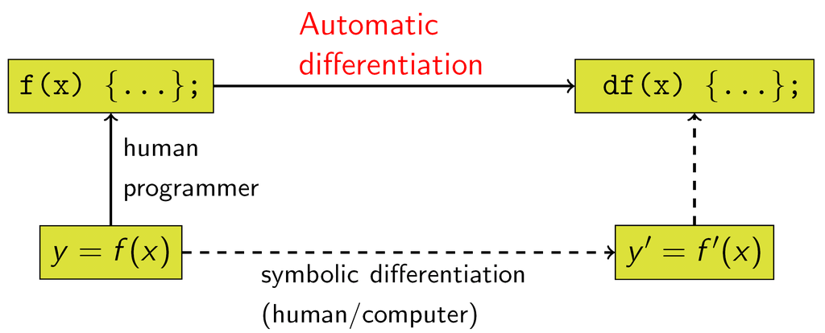

  [By Berland at en.wikipedia [Public domain], from Wikimedia Commons](https://commons.wikimedia.org/wiki/File%3AAutomaticDifferentiation.png)

## Example

- Suppose we want to differentiate $f(x_1,x_2) = x_1 x_2 + \sin x_1$
- We label subexpressions by $w_i$ as follows:
  $$\begin{array}{cl}
  f(x_1,x_2) &= x_1 x_2 + \sin x_1 \\
  &= w_1 w_2 + sin w_1 \\
  &= w_3 + w_4 \\
  &= w_5
  \end{array}$$
- Computation of the partial derivative starts with the seed value, i.e. $\dot{w}_1 = \frac{\partial x_1}{\partial x_1} = 1$.
- We store for each subexpression both the value and the derivative, i.e. $(w_i,\dot{w}_i)$
- We then sweep through the expression tree as in this picture:

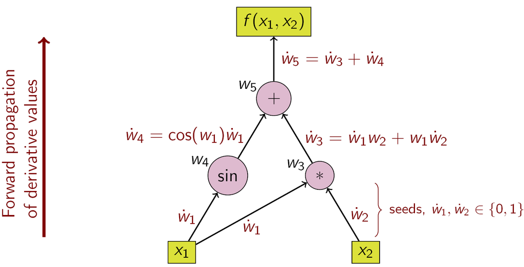

  [By Berland at en.wikipedia [Public domain], from Wikimedia Commons](https://commons.wikimedia.org/wiki/File%3AForwardAccumulationAutomaticDifferentiation.png)

# AD in Julia

- The organisation here is http://www.juliadiff.org
- There are many packages to perform differentiation with Julia here.
- Many packages rely on the machinery here.
- Let's quickly look at https://github.com/JuliaDiff/ForwardDiff.jl

```julia
# from ForwardDiff's readme:
using ForwardDiff
f(x::Vector) = sum(sin, x) + prod(tan, x) * sum(sqrt, x)
x = rand(5); # get 5 random points
g = ForwardDiff.gradient(f); # g = ∇f
j = ForwardDiff.jacobian(g); # j = J(∇f)
ForwardDiff.hessian(f, x) # H(f)(x) == J(∇f)(x), as expected
```

- The authors provide some benchmarks. Let's run those:

```julia
include(joinpath(Pkg.dir("ForwardDiff"),"benchmarks","run_all_benchmarks(ForwardDiffBenchmarks.Rosenbrock)"))
```

[output not shown]

# Numerical Approximation of Integrals

- We will focus on methods that represent integrals as weighted sums.
- The typical representation will look like:
  $$E[G(\epsilon)] = \int_{\mathbb{R}^N} G(\epsilon) w(\epsilon) d\epsilon \approx \sum_{j=1}^J \omega_j G(\epsilon_j)$$
  - $N$ is the dimensionality of the integration problem.
  - $G:\mathbb{R}^N \mapsto \mathbb{R}$ is the function we want to integrate wrt $\epsilon \in \mathbb{R}^N$.
  - $w$ is a density function s.t. $\int_{\mathbb{R}^n} w(\epsilon) d\epsilon = 1$.
  - $\omega$ are weights such that (most of the time) $\sum_{j=1}^J \omega_j = 1$.
- For now, let's say that $N=1$

# Quadrature Rules

- We focus exclusively on those and leave Simpson and Newton Cowtes formulas out.
  - This is because Quadrature is the method that in many situations gives highes accuracy with lowest computational cost.
- Quadrature provides a rule to compute weights $w_j$ and nodes $\epsilon_j$.
- There are many different quadrature rules.
- They differ in their domain and weighting function.
- https://en.wikipedia.org/wiki/Gaussian_quadrature
- In general, we can convert our function domain to a rule-specific domain with change of variables.

# Gauss-Hermite: Expectation of a Normally Distributed Variable

- There are many different rules, all specific to a certain random process.
- Gauss-Hermite is designed for an integral of the form
  $$\int_{-\infty}^{+\infty} e^{-x^2} G(x) dx$$
  and where we would approximate
  $$\int_{-\infty}^{+\infty} e^{-x^2} f(x) dx \approx \sum_{i=1}^n \omega_i G(x_i)$$
- Now, let's say we want to approximate the expected value of function $f$ when it's argument $z\sim N(\mu,\sigma^2)$:
  $$E[f(z)] = \int_{-\infty}^{+\infty} \frac{1}{\sigma \sqrt{2\pi}} \exp \left( -\frac{(z-\mu)^2}{2\sigma^2} \right) f(z) dz$$

# Gauss-Hermite: Expectation of a Normally Distributed Variable

# Using Quadrature in Julia

- https://github.com/ajt60gaibb/FastGaussQuadrature.jl

```julia
Pkg.add("FastGaussQuadrature")

using FastGaussQuadrature

np = 3

rules = Dict("hermite" => gausshermite(np),
             "chebyshev" => gausschebyshev(np),
             "legendre" => gausslegendre(np),
             "lobatto" => gausslobatto(np))


using DataFrames

nodes = DataFrame([x[1] for x in values(rules)],Symbol[symbol(x) for x in keys(rules)])
weights = DataFrame([x[2] for x in values(rules)],Symbol[symbol(x) for x in keys(rules)])
```

# Quadrature in more dimensions: Product Rule

- If we have $N>1$, we can use the product rule: this just takes the kronecker product of all univariate rules.
- This works well as long as $N$ is not too large. The number of required function evaluations grows exponentially.
  $$E[G(\epsilon)] = \int_{\mathbb{R}^N} G(\epsilon) w(\epsilon) d\epsilon \approx \sum_{j_1=1}^{J_1} \cdots \sum_{j_N=1}^{J_N} \omega_{j_1}^1 \cdots \omega_{j_N}^N G(\epsilon_{j_1}^1,\dots,\epsilon_{j_N}^N)$$
  where $\omega_{j_1}^1$ stands for weight index $j_1$ in dimension 1, same for $\epsilon$.
- Total number of nodes: $J=J_1 J_2 \cdots J_N$, and $J_i$ can differ from $J_k$.

## Example for $N=3$

- Suppose we have $\epsilon^i \sim N(0,1),i=1,2,3$ as three uncorrelated random variables.
- Let's take $J=3$ points in all dimensions, so that in total we have $J^N=27$ points.
- We have the nodes and weights from before in `rules["hermite"]`.

```julia
nodes = Any[]
push!(nodes,repeat(rules["hermite"][1],inner=[1],outer=[9]))
push!(nodes,repeat(rules["hermite"][1],inner=[3],outer=[3]))
push!(nodes,repeat(rules["hermite"][1],inner=[9],outer=[1]))
weights = kron(rules["hermite"][2],kron(rules["hermite"][2],rules["hermite"][2]))
df = hcat(DataFrame(weights=weights),DataFrame(nodes,[:dim1,:dim2,:dim3]))
```

- Imagine you had a function $g$ defined on those 3 dims: in order to approximate the integral, you would have to evaluate $g$ at all combinations of `dimx`, multiply with the corresponding weight, and sum.

# Alternatives to the Product Rule

- Monomial Rules: They grow only linearly.
- Please refer to (Judd 1998) for more details.

# Monte Carlo Integration

- A widely used method is to just draw $N$ points randomly from the space of the shock $\epsilon$, and to assign equal weights $\omega_j=\frac{1}{N}$ to all of them.
- The expectation is then
  $$E[G(\epsilon)] \approx \frac{1}{N} \sum_{j=1}^N G(\epsilon_j)$$
- This in general a very inefficient method.
- Particularly in more than 1 dimensions, the number of points needed for good accuracy is very large.

## Quasi Monte Carlo Integration

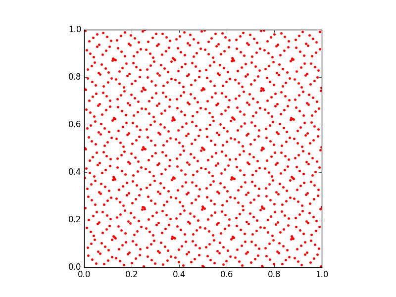

Sobol Sequences in [0,1]^2

```julia
Pkg.add("Sobol")
using Sobol
using PyPlot
s = SobolSeq(2)
p = hcat([next(s) for i = 1:1024]...)'
subplot(111, aspect="equal")
plot(p[:,1], p[:,2], "r.")
```

# Correlated Shocks

- We often face situations where the shocks are in fact correlated.
  - One very typical case is an AR1 process:
    $$z_{t+1} = \rho z_t + \varepsilon_t, \varepsilon \sim N(0,\sigma^2)$$
- The general case is again:
  $$E[G(\epsilon)] = \int_{\mathbb{R}^N} G(\epsilon) w(\epsilon) d\epsilon \approx \sum_{j_1=1}^{J_1} \cdots \sum_{j_N=1}^{J_N} \omega_{j_1}^1 \cdots \omega_{j_N}^N G(\epsilon_{j_1}^1,\dots,\epsilon_{j_N}^N)$$
- Now $\epsilon \sim N(\mu,\Sigma)$ where $\Sigma$ is an N by N variance-covariance matrix.
- The multivariate density is
  $$w(\epsilon) = (2\pi)^{-N/2} det(\Sigma)^{-1/2} \exp \left(-\frac{1}{2}(\epsilon - \mu)^T (\epsilon - \mu) \right)$$
- We need to perform a change of variables before we can integrate this.
- Given $\Sigma$ is symmetric and positive semi-definite, it has a Cholesky decomposition,
  $$\Sigma = \Omega \Omega^T$$
  where $\Omega$ is a lower-triangular with strictly positive entries.
- The linear change of variables is then
  $$v = \Omega^{-1} (\epsilon - \mu)$$
- Plugging this in gives
  $$\sum_{j=1}^J \omega_j G(\Omega v_j + \mu) \equiv \sum_{j=1}^J \omega_j G(\epsilon_j)$$
  where $v\sim N(0,I_N)$.
- So, we can follow the exact same steps as with the uncorrelated shocks, but need to adapt the nodes.

# References

- The Integration part of these slides are based on (L. Maliar and Maliar 2013) chapter 5

Judd, K. L. (1998). *Numerical methods in economics*. The MIT Press.

Maliar, L., & Maliar, S. (2013). Numerical methods for large scale dynamic economic models. *Handbook of Computational Economics*, *3*, 325. doi:http://dx.doi.org/10.1016/B978-0-444-52980-0.00007-4